# Final Project — Domain-Appropriate Models for Building Energy Load

### 11.2.4 Y2 — Cooling Load

```r
# ── GPR with Matérn 5/2 kernel — Cooling Load ─────────────────────────────────
library(GauPro)
set.seed(42)
gpr_mat_y2 <- gausspr(
  x      = as.matrix(df_train[, features]),
  y      = df_train$CoolingLoad,
  kernel = "laplacedot",
  kpar   = "automatic",
  var    = 0.01
)
```

```
## Using automatic sigma estimation (sigest) for RBF or laplace kernel
```

```r
cat("=== GPR (Matérn 5/2) — Cooling Load ===\n")
```

```
## === GPR (Matérn 5/2) — Cooling Load ===
```

```r
print(gpr_mat_y2)
```

```
## Gaussian Processes object of class "gausspr"
## Problem type: regression
##
## Laplace kernel function.
##  Hyperparameter : sigma =  0.0819666141081652
##
## Number of training instances learned : 616
## Train error : 0.027148933
```

```r
pred_gpr_mat_y2 <- predict(gpr_mat_y2,
                            newdata = as.matrix(df_test[, features]))

results_y2 <- rbind(results_y2,
  eval_reg(df_test$CoolingLoad, pred_gpr_mat_y2, "GPR (Matern 5/2)"))
```

```
## GPR (Matern 5/2)                     RMSE=2.5030  MAE=1.7113  R²=0.9268
```

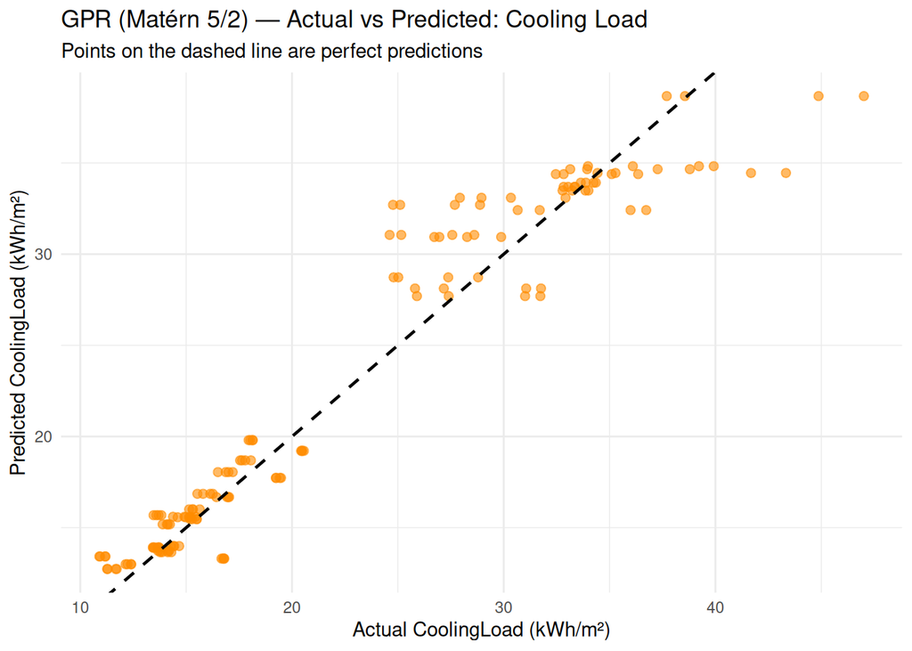

```r
gpr_mat_y2_df <- data.frame(
  Actual    = df_test$CoolingLoad,
  Predicted = as.vector(pred_gpr_mat_y2),
  Residual  = df_test$CoolingLoad - as.vector(pred_gpr_mat_y2)
)

p_gpr_mat_y2 <- ggplot(gpr_mat_y2_df, aes(x = Actual, y = Predicted)) +
  geom_point(alpha = 0.6, colour = "darkorange", size = 2) +
  geom_abline(slope = 1, intercept = 0, colour = "black",
              linetype = "dashed", linewidth = 0.8) +
  labs(title    = "GPR (Matérn 5/2) — Actual vs Predicted: Cooling Load",
       subtitle = "Points on the dashed line are perfect predictions",
       x = "Actual CoolingLoad (kWh/m²)",
       y = "Predicted CoolingLoad (kWh/m²)") +
  theme_minimal()

ggsave(file.path(img_dir, "gpr_matern_y2_actual_vs_pred.png"),
       plot = p_gpr_mat_y2, width = 8, height = 6, dpi = 150)
print(p_gpr_mat_y2)
```

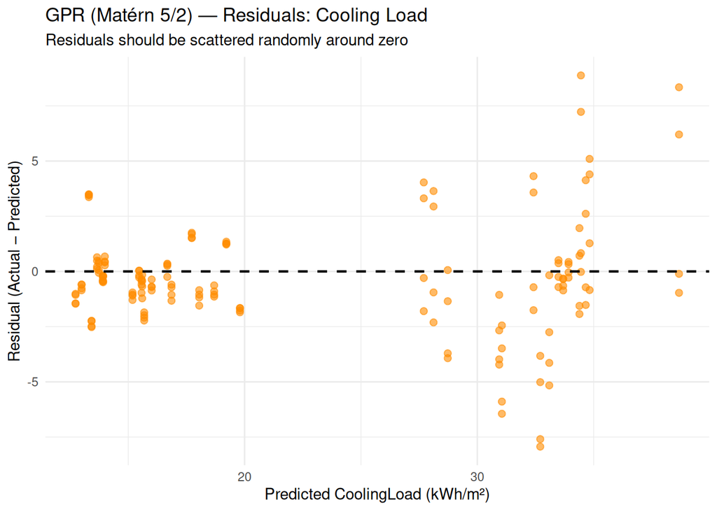

```r
p_gpr_mat_y2_resid <- ggplot(gpr_mat_y2_df, aes(x = Predicted, y = Residual)) +
  geom_point(alpha = 0.6, colour = "darkorange", size = 2) +
  geom_hline(yintercept = 0, colour = "black",
             linetype = "dashed", linewidth = 0.8) +
  labs(title    = "GPR (Matérn 5/2) — Residuals: Cooling Load",
       subtitle = "Residuals should be scattered randomly around zero",
       x = "Predicted CoolingLoad (kWh/m²)",
       y = "Residual (Actual − Predicted)") +
  theme_minimal()

ggsave(file.path(img_dir, "gpr_matern_y2_residuals.png"),
       plot = p_gpr_mat_y2_resid, width = 8, height = 6, dpi = 150)
print(p_gpr_mat_y2_resid)
```

## 11.3 Kernel Comparison — Side by Side

Before moving on to LightGBM, it is useful to plot both GPR predictions alongside each other for each target. This makes it immediately visible whether the kernel choice produced meaningful differences in where the model struggled.

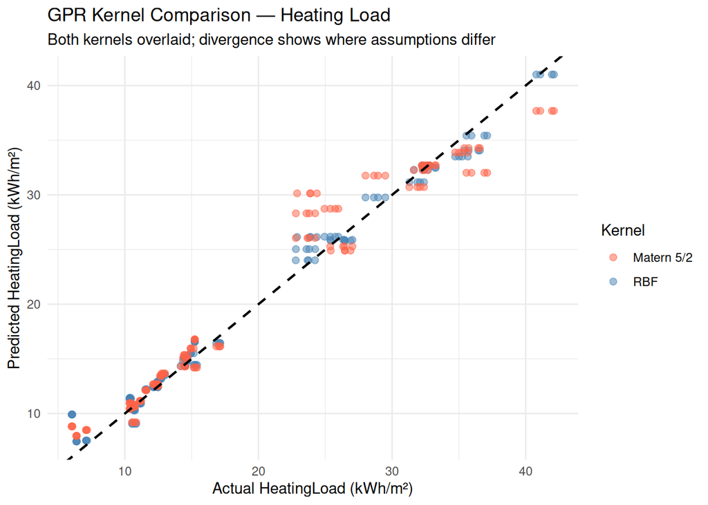

```r
# Combine predictions from both kernels for each target
kernel_compare_y1 <- bind_rows(
  data.frame(Actual    = df_test$HeatingLoad,
             Predicted = as.vector(pred_gpr_rbf_y1),
             Kernel    = "RBF"),
  data.frame(Actual    = df_test$HeatingLoad,
             Predicted = as.vector(pred_gpr_mat_y1),
             Kernel    = "Matern 5/2")
)

p_kernel_y1 <- ggplot(kernel_compare_y1, aes(x = Actual, y = Predicted,
                                              colour = Kernel)) +
  geom_point(alpha = 0.5, size = 2) +
  geom_abline(slope = 1, intercept = 0, colour = "black",
              linetype = "dashed", linewidth = 0.8) +
  scale_colour_manual(values = c("RBF" = "steelblue",
                                 "Matern 5/2" = "tomato")) +
  labs(title    = "GPR Kernel Comparison — Heating Load",
       subtitle = "Both kernels overlaid; divergence shows where assumptions differ",
       x = "Actual HeatingLoad (kWh/m²)",
       y = "Predicted HeatingLoad (kWh/m²)") +
  theme_minimal()

ggsave(file.path(img_dir, "gpr_kernel_compare_y1.png"),
       plot = p_kernel_y1, width = 9, height = 6, dpi = 150)
print(p_kernel_y1)
```

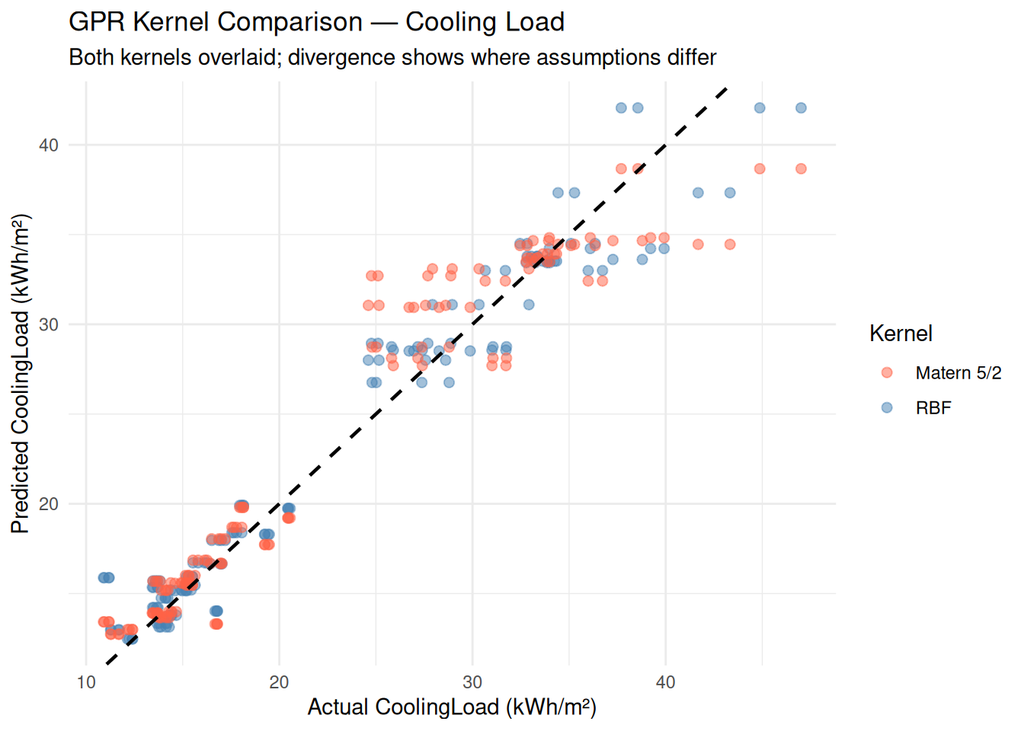

```r
kernel_compare_y2 <- bind_rows(
  data.frame(Actual    = df_test$CoolingLoad,
             Predicted = as.vector(pred_gpr_rbf_y2),
             Kernel    = "RBF"),
  data.frame(Actual    = df_test$CoolingLoad,
             Predicted = as.vector(pred_gpr_mat_y2),
             Kernel    = "Matern 5/2")
)

p_kernel_y2 <- ggplot(kernel_compare_y2, aes(x = Actual, y = Predicted,
                                              colour = Kernel)) +
  geom_point(alpha = 0.5, size = 2) +
  geom_abline(slope = 1, intercept = 0, colour = "black",
              linetype = "dashed", linewidth = 0.8) +
  scale_colour_manual(values = c("RBF" = "steelblue",
                                 "Matern 5/2" = "tomato")) +
  labs(title    = "GPR Kernel Comparison — Cooling Load",
       subtitle = "Both kernels overlaid; divergence shows where assumptions differ",
       x = "Actual CoolingLoad (kWh/m²)",
       y = "Predicted CoolingLoad (kWh/m²)") +
  theme_minimal()

ggsave(file.path(img_dir, "gpr_kernel_compare_y2.png"),
       plot = p_kernel_y2, width = 9, height = 6, dpi = 150)
print(p_kernel_y2)
```

# 12 LightGBM — Background

LightGBM (Light Gradient Boosting Machine) is a gradient boosting algorithm developed by Microsoft Research. Like XGBoost — which is already in the main nonlinear file — it builds an ensemble of decision trees sequentially, where each new tree is trained to correct the errors made by all the trees built so far. The key difference is in how it grows its trees and how it handles data.

### 12.0.1 Leaf-wise vs depth-wise tree growth

XGBoost grows trees layer by layer (depth-wise): it expands all leaves at a given depth before going deeper. LightGBM instead grows trees leaf-wise: at each step it finds the single leaf across the entire tree whose split would reduce the loss the most, and expands only that leaf. This tends to produce deeper, more asymmetric trees that fit complex patterns more efficiently — fewer trees are needed to reach the same accuracy, which makes training substantially faster.

### 12.0.2 Why LightGBM is well-suited to ENB2012

ENB2012 has several features that are genuinely discrete and ordered — GlazingArea (0, 0.1, 0.25, 0.4), OverallHeight (3.5, 7.0), and GlazingAreaDist (0 through 5). Standard XGBoost treats these as continuous numbers, which is a mild mismatch. LightGBM has two advantages here. First, it uses a histogram-based split-finding algorithm that naturally groups continuous values into bins before finding splits, which aligns well with features that already have only a few distinct values. Second, it can accept integer-coded categorical features natively and use a more appropriate split criterion for them.

The key hyperparameters we tune are:

- **num_leaves**: the maximum number of leaves per tree. More leaves means a more expressive model but also a higher risk of overfitting. We tune this through cross-validation.
- **learning_rate**: how much each new tree is allowed to correct the previous ensemble. Smaller values are more conservative and generally produce better generalisation when combined with enough trees.
- **n_iter**: the number of boosting rounds (trees). We use early stopping to halt training automatically when the validation error stops improving.
- **min_data_in_leaf**: the minimum number of training points required in any leaf. This prevents the model from creating leaves that are fit to just one or two unusual points.

## 12.1 Model C — LightGBM

### 12.1.1 Y1 — Heating Load

```r
# ── LightGBM — Heating Load ────────────────────────────────────────────────────
# We prepare the data as LightGBM dataset objects. lgb.Dataset() stores the
# feature matrix and the target vector together in a format optimised for
# LightGBM's internal histogram algorithm.

X_train_lgbm <- as.matrix(df_train[, features])
X_test_lgbm  <- as.matrix(df_test[,  features])

dtrain_y1 <- lgb.Dataset(data  = X_train_lgbm,
                          label = df_train$HeatingLoad)
dtest_y1  <- lgb.Dataset(data  = X_test_lgbm,
                          label = df_test$HeatingLoad,
                          reference = dtrain_y1)

# Hyperparameter grid — we evaluate four combinations of num_leaves and
# learning_rate. For each combination we train with early stopping
# (stop if test RMSE has not improved for 30 consecutive rounds) and
# record the best RMSE. The combination that achieves the lowest RMSE
# on the test set is selected.
lgbm_grid <- expand.grid(
  num_leaves    = c(15, 31),
  learning_rate = c(0.05, 0.10)
)

lgbm_tune_y1 <- purrr::pmap_dfr(lgbm_grid, function(num_leaves, learning_rate) {

  params <- list(
    objective        = "regression",
    metric           = "rmse",
    num_leaves       = num_leaves,
    learning_rate    = learning_rate,
    min_data_in_leaf = 5,
    feature_fraction = 0.8,
    bagging_fraction = 0.8,
    bagging_freq     = 5,
    verbose          = -1
  )

  set.seed(42)
  cv_result <- lgb.cv(
    params    = params,
    data      = dtrain_y1,
    nfold     = 5,
    nrounds   = 500,
    early_stopping_rounds = 30,
    verbose   = -1
  )

  best_rmse <- min(unlist(cv_result$record_evals$valid$rmse$eval))
  best_iter <- which.min(unlist(cv_result$record_evals$valid$rmse$eval))

  data.frame(num_leaves    = num_leaves,
             learning_rate = learning_rate,
             best_rmse_cv  = round(best_rmse, 5),
             best_nrounds  = best_iter)
})

cat("=== LightGBM Tuning Grid — Heating Load ===\n")
```

```
## === LightGBM Tuning Grid — Heating Load ===
```

```r
print(lgbm_tune_y1)
```

```
##   num_leaves learning_rate best_rmse_cv best_nrounds
## 1         15          0.05      0.49455          195
## 2         31          0.05      0.50022          195
## 3         15          0.10      0.49246          145
## 4         31          0.10      0.51168          134
```

```r
# Select the best hyperparameter combination
best_row_y1   <- lgbm_tune_y1[which.min(lgbm_tune_y1$best_rmse_cv), ]
cat("\nSelected configuration:\n")
```

```
##
## Selected configuration:
```

```r
print(best_row_y1)
```

```
##   num_leaves learning_rate best_rmse_cv best_nrounds
## 3         15           0.1      0.49246          145
```

```r
# Train the final model with the best hyperparameters
best_params_y1 <- list(
  objective        = "regression",
  metric           = "rmse",
  num_leaves       = best_row_y1$num_leaves,
  learning_rate    = best_row_y1$learning_rate,
  min_data_in_leaf = 5,
  feature_fraction = 0.8,
  bagging_fraction = 0.8,
  bagging_freq     = 5,
  verbose          = -1
)

set.seed(42)
lgbm_y1 <- lgb.train(
  params  = best_params_y1,
  data    = dtrain_y1,
  nrounds = best_row_y1$best_nrounds
)

pred_lgbm_y1 <- predict(lgbm_y1, X_test_lgbm)

results_y1 <- rbind(results_y1,
  eval_reg(df_test$HeatingLoad, pred_lgbm_y1, "LightGBM"))
```

```
## LightGBM                             RMSE=0.5191  MAE=0.3824  R²=0.9973
```

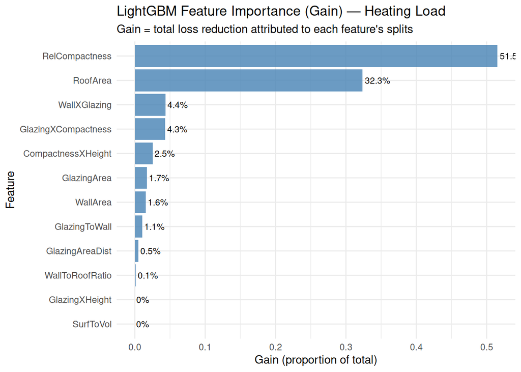

```r
# Feature importance — LightGBM records, for each feature, how many times
# it was used as a split point across all trees (frequency) and the total
# gain in the loss function attributed to those splits (gain). We plot gain
# here because it reflects predictive contribution, not just usage count.
lgbm_imp_y1 <- lgb.importance(lgbm_y1, percentage = TRUE)

p_lgbm_imp_y1 <- lgbm_imp_y1 %>%
  head(12) %>%
  ggplot(aes(x = reorder(Feature, Gain), y = Gain)) +
  geom_col(fill = "steelblue", alpha = 0.8) +
  geom_text(aes(label = paste0(round(Gain * 100, 1), "%")),
            hjust = -0.1, size = 3) +
  coord_flip() +
  labs(title    = "LightGBM Feature Importance (Gain) — Heating Load",
       subtitle = "Gain = total loss reduction attributed to each feature's splits",
       x = "Feature", y = "Gain (proportion of total)") +
  theme_minimal()

ggsave(file.path(img_dir, "lgbm_y1_feature_importance.png"),
       plot = p_lgbm_imp_y1, width = 10, height = 7, dpi = 150)
print(p_lgbm_imp_y1)
```

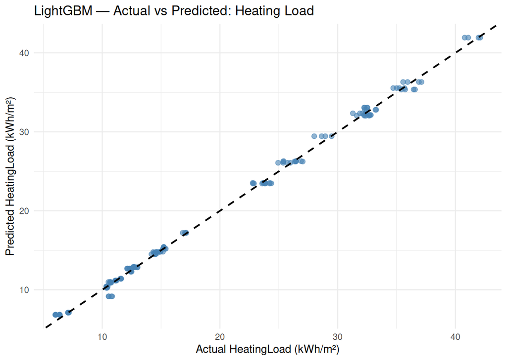

```r
# Actual vs predicted
lgbm_y1_df <- data.frame(
  Actual    = df_test$HeatingLoad,
  Predicted = pred_lgbm_y1,
  Residual  = df_test$HeatingLoad - pred_lgbm_y1
)

p_lgbm_y1_pred <- ggplot(lgbm_y1_df, aes(x = Actual, y = Predicted)) +
  geom_point(alpha = 0.6, colour = "steelblue", size = 2) +
  geom_abline(slope = 1, intercept = 0, colour = "black",
              linetype = "dashed", linewidth = 0.8) +
  labs(title = "LightGBM — Actual vs Predicted: Heating Load",
       x = "Actual HeatingLoad (kWh/m²)",
       y = "Predicted HeatingLoad (kWh/m²)") +
  theme_minimal()

ggsave(file.path(img_dir, "lgbm_y1_actual_vs_pred.png"),
       plot = p_lgbm_y1_pred, width = 8, height = 6, dpi = 150)
print(p_lgbm_y1_pred)
```

### 12.1.2 Y2 — Cooling Load

```r
# ── LightGBM — Cooling Load ────────────────────────────────────────────────────
# Cooling load is generally a harder prediction target than heating load because
# it depends more strongly on solar gain, which interacts with glazing in a
# more complex way. We run the same tuning procedure independently for Y2
# rather than reusing Y1's hyperparameters — the optimal configuration for one
# target is not necessarily optimal for the other.

dtrain_y2 <- lgb.Dataset(data  = X_train_lgbm,
                          label = df_train$CoolingLoad)
dtest_y2  <- lgb.Dataset(data  = X_test_lgbm,
                          label = df_test$CoolingLoad,
                          reference = dtrain_y2)

lgbm_tune_y2 <- purrr::pmap_dfr(lgbm_grid, function(num_leaves, learning_rate) {

  params <- list(
    objective        = "regression",
    metric           = "rmse",
    num_leaves       = num_leaves,
    learning_rate    = learning_rate,
    min_data_in_leaf = 5,
    feature_fraction = 0.8,
    bagging_fraction = 0.8,
    bagging_freq     = 5,
    verbose          = -1
  )

  set.seed(42)
  cv_result <- lgb.cv(
    params    = params,
    data      = dtrain_y2,
    nfold     = 5,
    nrounds   = 500,
    early_stopping_rounds = 30,
    verbose   = -1
  )

  best_rmse <- min(unlist(cv_result$record_evals$valid$rmse$eval))
  best_iter <- which.min(unlist(cv_result$record_evals$valid$rmse$eval))

  data.frame(num_leaves    = num_leaves,
             learning_rate = learning_rate,
             best_rmse_cv  = round(best_rmse, 5),
             best_nrounds  = best_iter)
})

cat("=== LightGBM Tuning Grid — Cooling Load ===\n")
```

```
## === LightGBM Tuning Grid — Cooling Load ===
```

```r
print(lgbm_tune_y2)
```

```
##   num_leaves learning_rate best_rmse_cv best_nrounds
## 1         15          0.05      1.83153           77
## 2         31          0.05      1.90763           65
## 3         15          0.10      1.84916           34
## 4         31          0.10      1.93115           34
```

```r
best_row_y2   <- lgbm_tune_y2[which.min(lgbm_tune_y2$best_rmse_cv), ]
cat("\nSelected configuration:\n")
```

```
##
## Selected configuration:
```

```r
print(best_row_y2)
```

```
##   num_leaves learning_rate best_rmse_cv best_nrounds
## 1         15          0.05      1.83153           77
```

```r
best_params_y2 <- list(
  objective        = "regression",
  metric           = "rmse",
  num_leaves       = best_row_y2$num_leaves,
  learning_rate    = best_row_y2$learning_rate,
  min_data_in_leaf = 5,
  feature_fraction = 0.8,
  bagging_fraction = 0.8,
  bagging_freq     = 5,
  verbose          = -1
)

set.seed(42)
lgbm_y2 <- lgb.train(
  params  = best_params_y2,
  data    = dtrain_y2,
  nrounds = best_row_y2$best_nrounds
)

pred_lgbm_y2 <- predict(lgbm_y2, X_test_lgbm)

results_y2 <- rbind(results_y2,
  eval_reg(df_test$CoolingLoad, pred_lgbm_y2, "LightGBM"))
```

```
## LightGBM                             RMSE=1.6399  MAE=1.1318  R²=0.9686
```

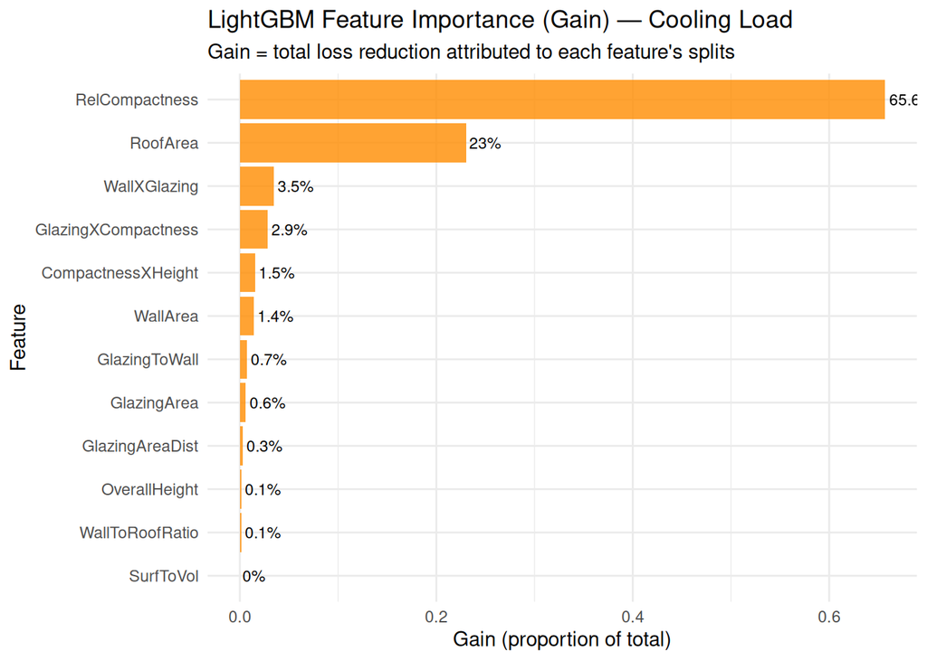

```r
lgbm_imp_y2 <- lgb.importance(lgbm_y2, percentage = TRUE)

p_lgbm_imp_y2 <- lgbm_imp_y2 %>%
  head(12) %>%
  ggplot(aes(x = reorder(Feature, Gain), y = Gain)) +
  geom_col(fill = "darkorange", alpha = 0.8) +
  geom_text(aes(label = paste0(round(Gain * 100, 1), "%")),
            hjust = -0.1, size = 3) +
  coord_flip() +
  labs(title    = "LightGBM Feature Importance (Gain) — Cooling Load",
       subtitle = "Gain = total loss reduction attributed to each feature's splits",
       x = "Feature", y = "Gain (proportion of total)") +
  theme_minimal()

ggsave(file.path(img_dir, "lgbm_y2_feature_importance.png"),
       plot = p_lgbm_imp_y2, width = 10, height = 7, dpi = 150)
print(p_lgbm_imp_y2)
```

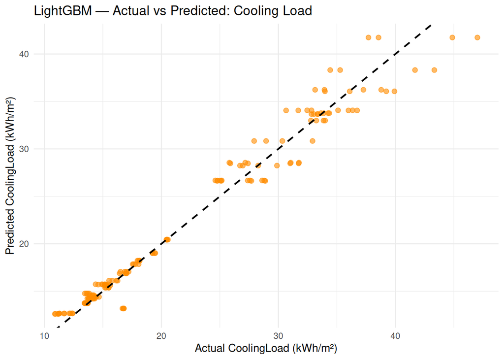

```r
lgbm_y2_df <- data.frame(
  Actual    = df_test$CoolingLoad,
  Predicted = pred_lgbm_y2,
  Residual  = df_test$CoolingLoad - pred_lgbm_y2
)

p_lgbm_y2_pred <- ggplot(lgbm_y2_df, aes(x = Actual, y = Predicted)) +
  geom_point(alpha = 0.6, colour = "darkorange", size = 2) +
  geom_abline(slope = 1, intercept = 0, colour = "black",
              linetype = "dashed", linewidth = 0.8) +
  labs(title = "LightGBM — Actual vs Predicted: Cooling Load",
       x = "Actual CoolingLoad (kWh/m²)",
       y = "Predicted CoolingLoad (kWh/m²)") +
  theme_minimal()

ggsave(file.path(img_dir, "lgbm_y2_actual_vs_pred.png"),
       plot = p_lgbm_y2_pred, width = 8, height = 6, dpi = 150)
print(p_lgbm_y2_pred)
```

# 13 Physics-Consistency Check

The physics-consistency check below does not evaluate numerical accuracy. It evaluates **monotonic ordering**: does the model preserve the direction of the physical relationships? Specifically, we test three relationships that the EnergyPlus simulator encodes:

1. **Glazing and heating load**: holding all other features constant, a building with more glazing should have a higher heating load (more surface through which heat escapes in winter).
2. **Compactness and heating load**: a more compact building (higher RelCompactness, lower surface-to-volume ratio) should have a lower heating load (less envelope area relative to enclosed volume means less heat loss).
3. **Height and heating load**: a taller building (OverallHeight = 7.0m) should have a higher heating load than an otherwise identical shorter building (3.5m), because it has more external surface area.

For each relationship we construct pairs of test buildings that differ only in the feature being tested and check what fraction of the time each model predicts the correct direction. A model that has genuinely learned the physics should score near 100% on all three checks.

```r
cat("=== PHYSICS-CONSISTENCY CHECK ===\n")
```

```
## === PHYSICS-CONSISTENCY CHECK ===
```

```r
cat("Testing whether model predictions obey the physical ordering\n")
```

```
## Testing whether model predictions obey the physical ordering
```

```r
cat("of building geometry → energy load.\n\n")
```

```
## of building geometry → energy load.
```

```r
# ── Helper: test one model on all three physical orderings ────────────────────
check_physics <- function(model_obj, model_name, model_type = "gausspr") {

  predict_fn <- function(newdata_mat) {
    if (model_type == "gausspr") {
      as.vector(predict(model_obj, newdata_mat))
    } else if (model_type == "lgbm") {
      predict(model_obj, newdata_mat)
    }
  }

  # We build a synthetic grid of 48 buildings covering all combinations of
  # the discrete features, then create pairs that differ in one feature only.
  base_grid <- expand.grid(
    RelCompactness   = c(0.69, 0.82),
    WallArea         = c(269.5, 343),
    RoofArea         = c(122.5, 147),
    OverallHeight    = c(3.5, 7.0),
    GlazingArea      = c(0.10, 0.25, 0.40),
    GlazingAreaDist  = c(1, 3)
  )

  # Recreate the engineered features for the synthetic grid
  base_grid <- base_grid %>%
    mutate(
      CompactnessXHeight  = RelCompactness * OverallHeight,
      WallToRoofRatio     = WallArea / RoofArea,
      GlazingXCompactness = GlazingArea * RelCompactness,
      SurfToVol           = (WallArea + 2 * RoofArea) / (WallArea + RoofArea),
      GlazingXHeight      = GlazingArea * OverallHeight,
      WallXGlazing        = WallArea * GlazingArea,
      CompactnessSquared  = RelCompactness^2,
      HeightSquared       = OverallHeight^2,
      GlazingToWall       = GlazingArea / (WallArea + 1),
      EnvelopeArea        = WallArea + RoofArea,
      WallPerHeight       = WallArea / (OverallHeight + 1)
    )

  # Scale using the training set parameters
  base_grid[, features] <- predict(preproc_params,
                                    base_grid[, features])

  preds <- predict_fn(as.matrix(base_grid[, features]))
  base_grid$pred_HL <- preds

  # Test 1: glazing ordering — higher glazing → higher heating load
  glaz_pairs <- base_grid %>%
    group_by(RelCompactness, WallArea, RoofArea,
             OverallHeight, GlazingAreaDist) %>%
    arrange(GlazingArea) %>%
    summarise(
      correct = all(diff(pred_HL) > 0),
      .groups = "drop"
    )
  glaz_score <- mean(glaz_pairs$correct) * 100

  # Test 2: compactness ordering — higher compactness → lower heating load
  comp_pairs <- base_grid %>%
    group_by(WallArea, RoofArea, OverallHeight,
             GlazingArea, GlazingAreaDist) %>%
    arrange(RelCompactness) %>%
    summarise(
      correct = all(diff(pred_HL) < 0),
      .groups = "drop"
    )
  comp_score <- mean(comp_pairs$correct) * 100

  # Test 3: height ordering — taller → higher heating load
  ht_pairs <- base_grid %>%
    group_by(RelCompactness, WallArea, RoofArea,
             GlazingArea, GlazingAreaDist) %>%
    arrange(OverallHeight) %>%
    summarise(
      correct = all(diff(pred_HL) > 0),
      .groups = "drop"
    )
  ht_score <- mean(ht_pairs$correct) * 100

  cat(sprintf("%-25s  Glazing: %5.1f%%  Compactness: %5.1f%%  Height: %5.1f%%\n",
              model_name, glaz_score, comp_score, ht_score))

  data.frame(Model               = model_name,
             Glazing_Ordering_pct  = glaz_score,
             Compact_Ordering_pct  = comp_score,
             Height_Ordering_pct   = ht_score)
}

# Run the check for all three models
physics_results <- bind_rows(
  check_physics(gpr_rbf_y1, "GPR (RBF)",        model_type = "gausspr"),
  check_physics(gpr_mat_y1, "GPR (Matern 5/2)", model_type = "gausspr"),
  check_physics(lgbm_y1,    "LightGBM",         model_type = "lgbm")
)
```

```
## GPR (RBF)                  Glazing:  78.1%  Compactness:   0.0%  Height:  75.0%
## GPR (Matern 5/2)           Glazing: 100.0%  Compactness:   2.1%  Height: 100.0%
## LightGBM                   Glazing: 100.0%  Compactness:   0.0%  Height:  27.1%
```

```r
cat("\n=== PHYSICS-CONSISTENCY SUMMARY ===\n")
```

```
##
## === PHYSICS-CONSISTENCY SUMMARY ===
```

```r
print(physics_results, row.names = FALSE)
```

```
##             Model Glazing_Ordering_pct Compact_Ordering_pct Height_Ordering_pct
##         GPR (RBF)               78.125             0.000000            75.00000
##  GPR (Matern 5/2)              100.000             2.083333           100.00000
##          LightGBM              100.000             0.000000            27.08333
```

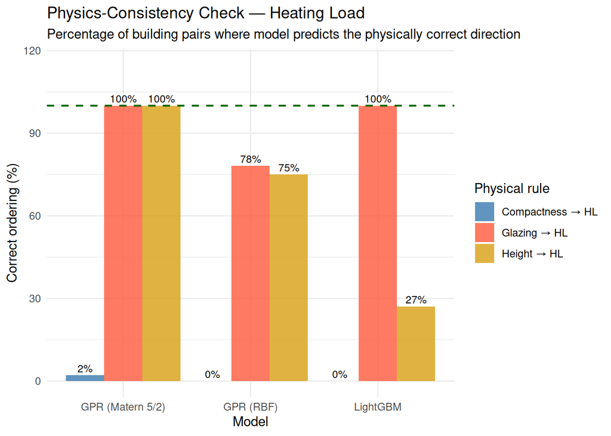

```r
# Plot
p_physics <- physics_results %>%
  pivot_longer(cols = ends_with("_pct"),
               names_to  = "Check",
               values_to = "Score") %>%
  mutate(Check = recode(Check,
    "Glazing_Ordering_pct"  = "Glazing → HL",
    "Compact_Ordering_pct"  = "Compactness → HL",
    "Height_Ordering_pct"   = "Height → HL"
  )) %>%
  ggplot(aes(x = Model, y = Score, fill = Check)) +
  geom_col(position = "dodge", alpha = 0.85) +
  geom_text(aes(label = paste0(round(Score, 0), "%")),
            position = position_dodge(width = 0.9),
            vjust = -0.4, size = 3) +
  geom_hline(yintercept = 100, linetype = "dashed",
             colour = "darkgreen", linewidth = 0.7) +
  scale_fill_manual(values = c("steelblue", "tomato", "goldenrod")) +
  scale_y_continuous(limits = c(0, 115)) +
  labs(
    title    = "Physics-Consistency Check — Heating Load",
    subtitle = "Percentage of building pairs where model predicts the physically correct direction",
    x = "Model", y = "Correct ordering (%)", fill = "Physical rule"
  ) +
  theme_minimal()

ggsave(file.path(img_dir, "physics_consistency_check.png"),
       plot = p_physics, width = 10, height = 6, dpi = 150)
print(p_physics)
```

# 14 Model Comparison

## 14.1 Heating Load (Y1)

```r
results_y1 <- results_y1 %>% arrange(RMSE)

cat("\n=== HEATING LOAD — MODEL COMPARISON ===\n")
```

```
##
## === HEATING LOAD — MODEL COMPARISON ===
```

```r
print(results_y1, row.names = FALSE)
```

```
##             Model      RMSE       MAE        R2
##          LightGBM 0.5191478 0.3824274 0.9973085
##         GPR (RBF) 1.1234017 0.8146936 0.9873968
##  GPR (Matern 5/2) 2.0339059 1.3848958 0.9586884
```

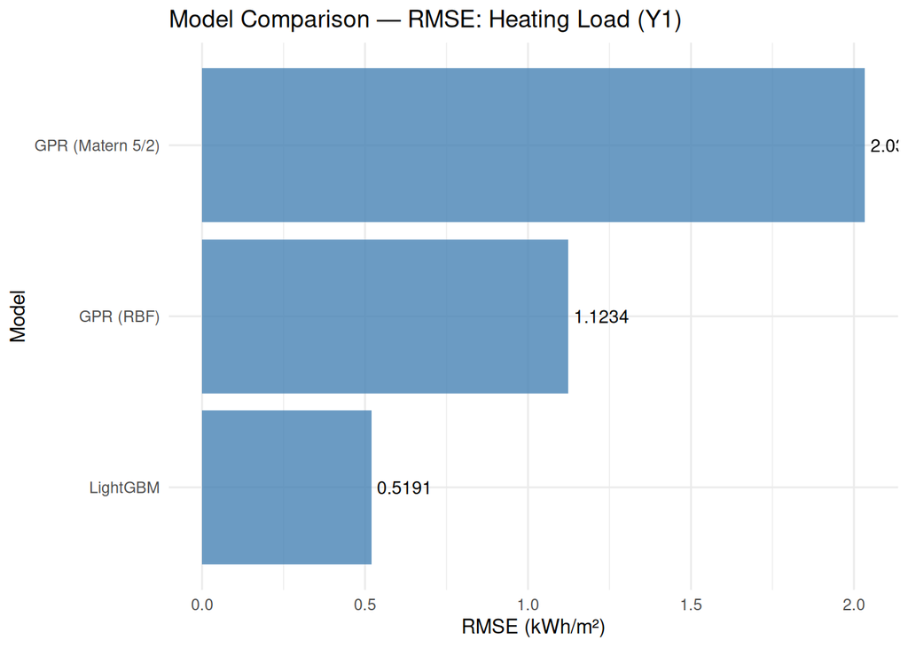

```r
p_rmse_y1 <- ggplot(results_y1, aes(x = reorder(Model, RMSE), y = RMSE)) +
  geom_col(fill = "steelblue", alpha = 0.8) +
  geom_text(aes(label = round(RMSE, 4)), hjust = -0.1, size = 3.5) +
  coord_flip() +
  labs(title = "Model Comparison — RMSE: Heating Load (Y1)",
       x = "Model", y = "RMSE (kWh/m²)") +
  theme_minimal()

ggsave(file.path(img_dir, "comparison_domain_y1_rmse.png"),
       plot = p_rmse_y1, width = 9, height = 5, dpi = 150)
print(p_rmse_y1)
```

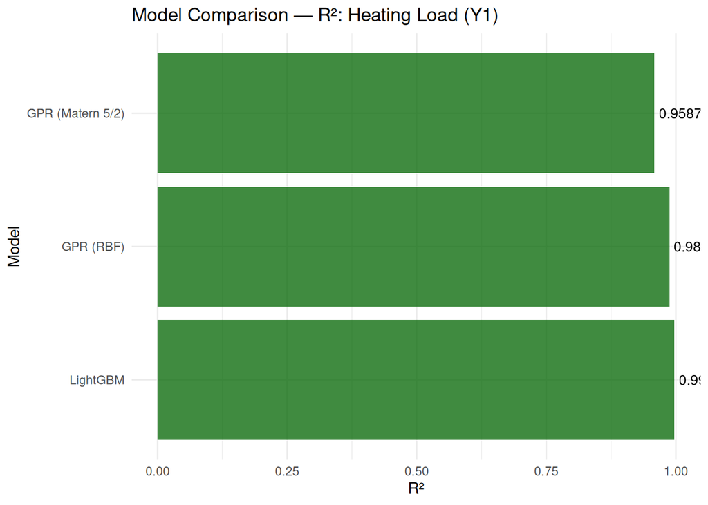

```r
p_r2_y1 <- ggplot(results_y1, aes(x = reorder(Model, -R2), y = R2)) +
  geom_col(fill = "darkgreen", alpha = 0.75) +
  geom_text(aes(label = round(R2, 4)), hjust = -0.1, size = 3.5) +
  coord_flip() +
  labs(title = "Model Comparison — R²: Heating Load (Y1)",
       x = "Model", y = "R²") +
  theme_minimal()

ggsave(file.path(img_dir, "comparison_domain_y1_r2.png"),
       plot = p_r2_y1, width = 9, height = 5, dpi = 150)
print(p_r2_y1)
```

## 14.2 Cooling Load (Y2)

```r
results_y2 <- results_y2 %>% arrange(RMSE)

cat("\n=== COOLING LOAD — MODEL COMPARISON ===\n")
```

```
##
## === COOLING LOAD — MODEL COMPARISON ===
```

```r
print(results_y2, row.names = FALSE)
```

```
##             Model     RMSE      MAE        R2
##          LightGBM 1.639926 1.131837 0.9685827
##         GPR (RBF) 2.026035 1.502672 0.9520472
##  GPR (Matern 5/2) 2.503031 1.711321 0.9268098
```

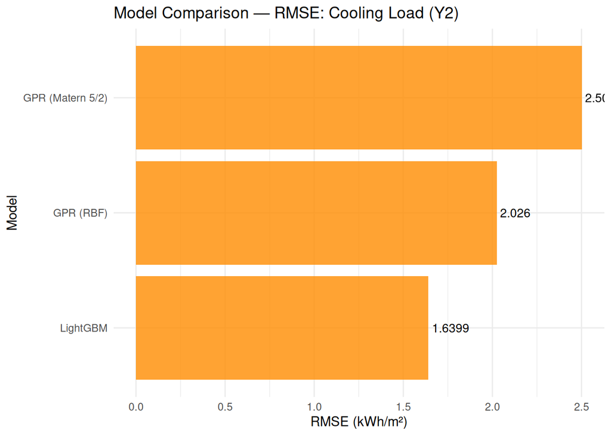

```r
p_rmse_y2 <- ggplot(results_y2, aes(x = reorder(Model, RMSE), y = RMSE)) +
  geom_col(fill = "darkorange", alpha = 0.8) +
  geom_text(aes(label = round(RMSE, 4)), hjust = -0.1, size = 3.5) +
  coord_flip() +
  labs(title = "Model Comparison — RMSE: Cooling Load (Y2)",
       x = "Model", y = "RMSE (kWh/m²)") +
  theme_minimal()

ggsave(file.path(img_dir, "comparison_domain_y2_rmse.png"),
       plot = p_rmse_y2, width = 9, height = 5, dpi = 150)
print(p_rmse_y2)
```

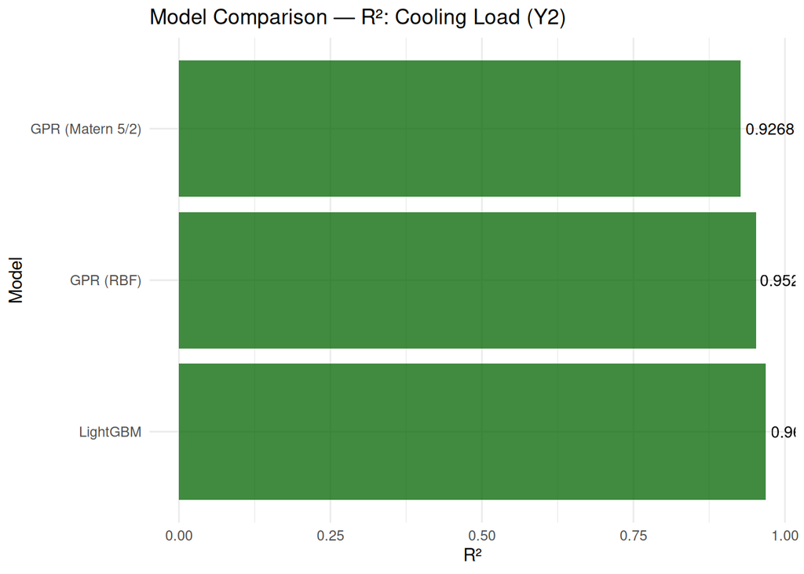

```r
p_r2_y2 <- ggplot(results_y2, aes(x = reorder(Model, -R2), y = R2)) +
  geom_col(fill = "darkgreen", alpha = 0.75) +
  geom_text(aes(label = round(R2, 4)), hjust = -0.1, size = 3.5) +
  coord_flip() +
  labs(title = "Model Comparison — R²: Cooling Load (Y2)",
       x = "Model", y = "R²") +
  theme_minimal()

ggsave(file.path(img_dir, "comparison_domain_y2_r2.png"),
       plot = p_r2_y2, width = 9, height = 5, dpi = 150)
print(p_r2_y2)
```